# DASM Practical 2

### Inspect Data

When you do this, you’ll notice that the data frame `df` appears in the `Environment` tab, and we can see that it has 1012 rows (observations) and 3 variables (columns).

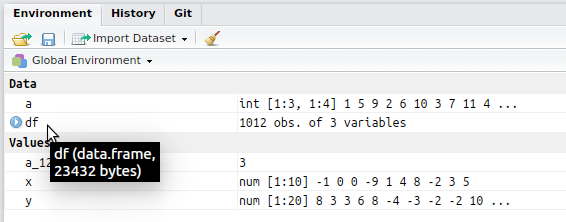

If you click this, you will be able to inspect the actual values in the data frame:

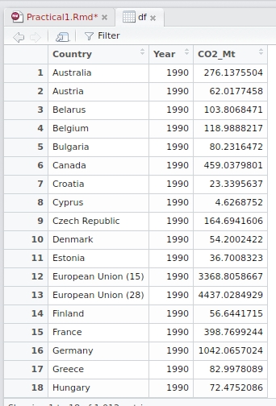

Use `summary` to get a quick overview of what is in the data:

```r
summary(df)
```

```
##    Country               Year          CO2_Mt
##  Length:1012        Min.   :1990   Min.   :   0.079
##  Class :character   1st Qu.:1995   1st Qu.:  27.274
##  Mode  :character   Median :2001   Median :  63.196
##                     Mean   :2001   Mean   : 496.211
##                     3rd Qu.:2007   3rd Qu.: 362.777
##                     Max.   :2012   Max.   :6116.441
```

From this we see that it contains data on years from 1990 until 2012.

If you have read everything in correctly, you should get the following values for the average and standard deviation of the `CO2_Mt` column.

```r
mean(df$CO2_Mt)
```

```
## [1] 496.2108
```

```r
sd(df$CO2_Mt)
```

```
## [1] 1132.462
```

Create line plots per country of the amount of CO2 emissions:

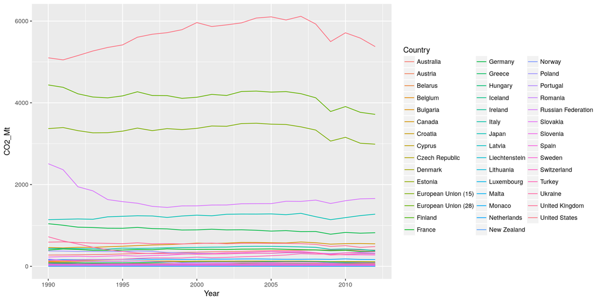

```r
ggplot(df, aes(x=Year, y=CO2_Mt, colour=Country)) + geom_line()
```

Create a stacked area chart showing how each country’s CO2 emissions contributes to the total:

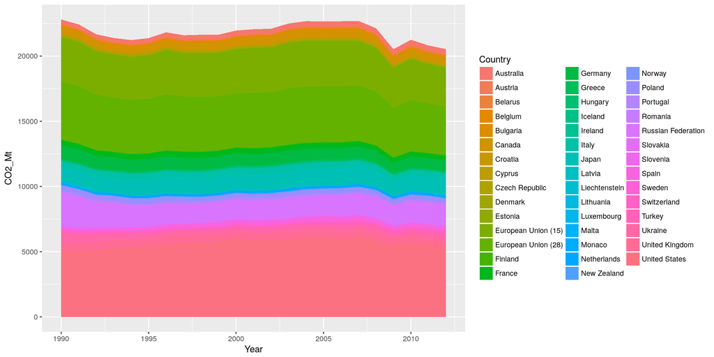

```r
ggplot(df,
       aes(x=Year, y=CO2_Mt, fill=Country)) +
  geom_area()
```

Same plot, but using `geom_line(aes(ymax=CO2_Mt), position="stack", size=0.1)` to add black lines to help better distinguish the individual countries.

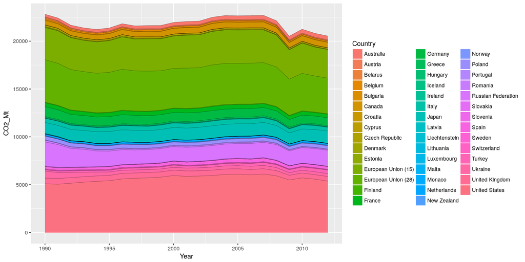

```r
ggplot(df,
       aes(x=Year, y=CO2_Mt, fill=Country)) +
  geom_area() +
  geom_line(aes(ymax=CO2_Mt), position="stack", size=0.1)
```

In the previous plots, it’s a bit difficult to distinguish countries with similar colors. We can also use `facet_wrap` to create plots for individual countries.

- `~Country` - create individual plots per distinct values in the `Country` column.
- `scales="free_y"` - each plot will have its y axis scaled individually. This helps to view the trends from countries with less CO2 emissions.

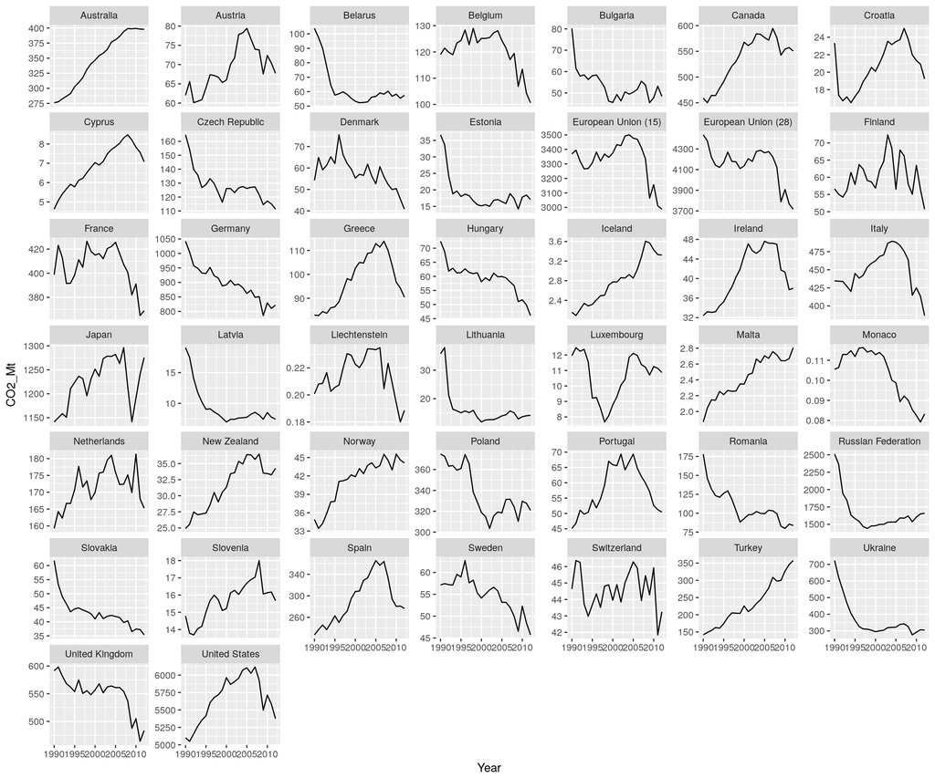

```r
ggplot(df, aes(x=Year, y=CO2_Mt)) + geom_line() + facet_wrap(~Country, scales="free_y")
```

The plot above shows the variation, but you’ll notice that the minimum value on the y scale is not set to zero. This means that the variation observed may not actually be that big when considering the overall amount of emissions. To fix this, we update our code to use `ymin=0` so that we can get a picture of the absolute magnitude of emissions.

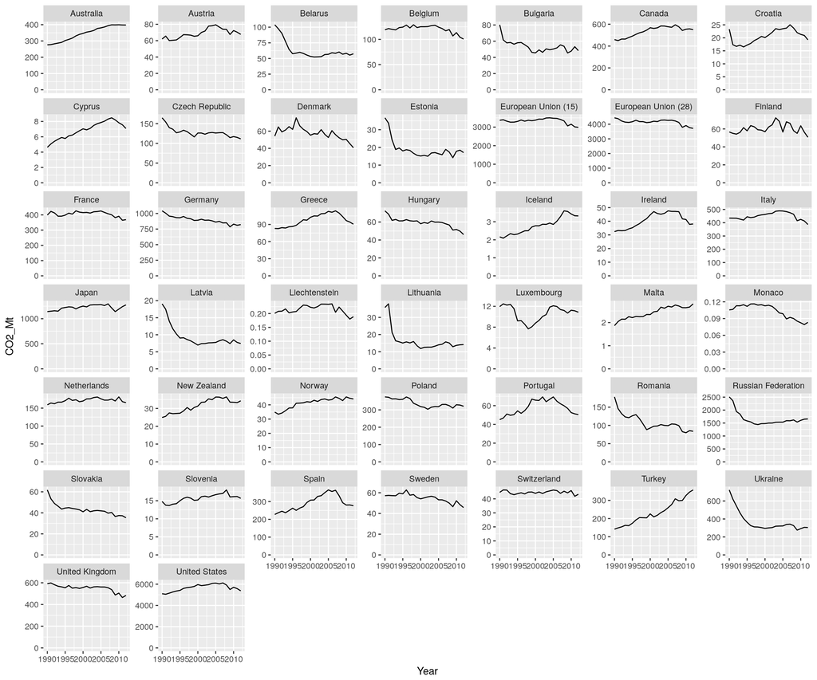

```r
ggplot(df, aes(x=Year, y=CO2_Mt, ymin=0)) + geom_line() + facet_wrap(~Country, scales="free_y")
```